# Final Part 2- Analyzing Delomys Species Data

Mercy Melo

12/7/2021

# Numerical Exploration

Delomys data structure exploration:

```r
summary(delomys)
```

```
##        X            genus             binomial           body_mass
##  Min.   :27526   Length:1585        Length:1585        Min.   :  5.00
##  1st Qu.:27950   Class :character   Class :character   1st Qu.: 35.00
##  Median :28348   Mode  :character   Mode  :character   Median : 43.00
##  Mean   :28371                                         Mean   : 44.06
##  3rd Qu.:28790                                         3rd Qu.: 54.00
##  Max.   :35552                                         Max.   :105.00
##   body_length        age                sex              longitude
##  Min.   : 49.0   Length:1585        Length:1585        Min.   :-49681671
##  1st Qu.:106.0   Class :character   Class :character   1st Qu.:      -50
##  Median :116.0   Mode  :character   Mode  :character   Median :      -50
##  Mean   :114.7                                         Mean   :   -62739
##  3rd Qu.:124.0                                         3rd Qu.:      -47
##  Max.   :265.0                                         Max.   :      -41
##     latitude            status
##  Min.   :-22383667   Length:1585
##  1st Qu.:      -29   Class :character
##  Median :      -29   Mode  :character
##  Mean   :   -28272
##  3rd Qu.:      -24
##  Max.   :      -20
```

Test of normality:

```r
shapiro.test(delomys$body_mass)
```

```
##
##  Shapiro-Wilk normality test
##
## data:  delomys$body_mass
## W = 0.99506, p-value = 4.33e-05
```

```r
shapiro.test(delomys$body_length)
```

```
##
##  Shapiro-Wilk normality test
##
## data:  delomys$body_length
## W = 0.87609, p-value < 2.2e-16
```

# Graphical Exploration

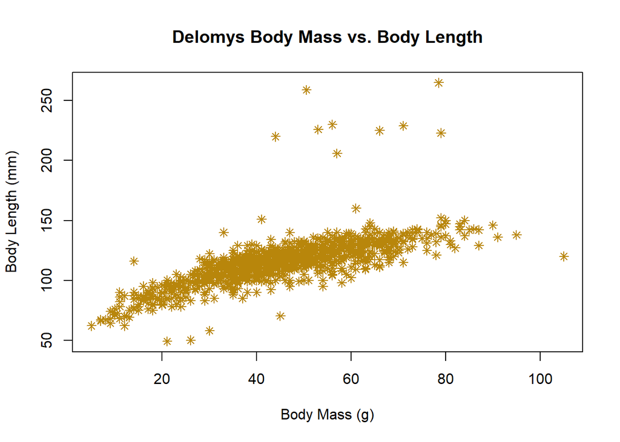

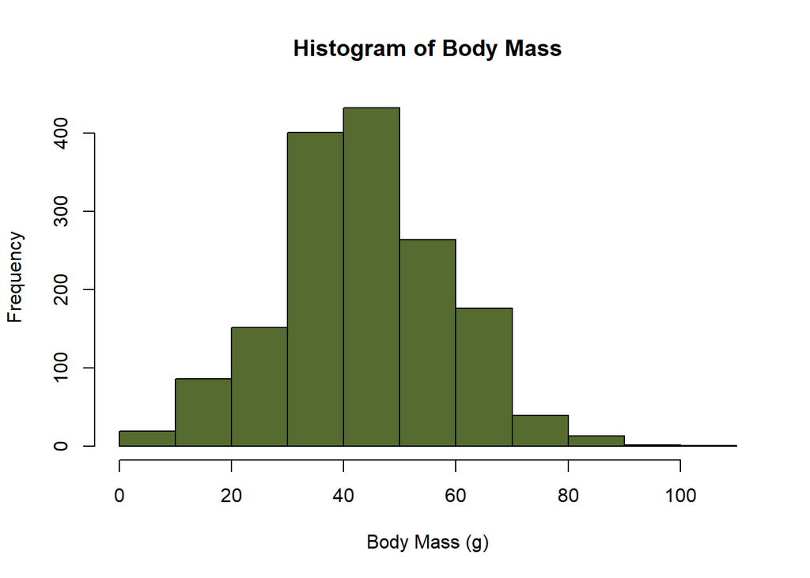

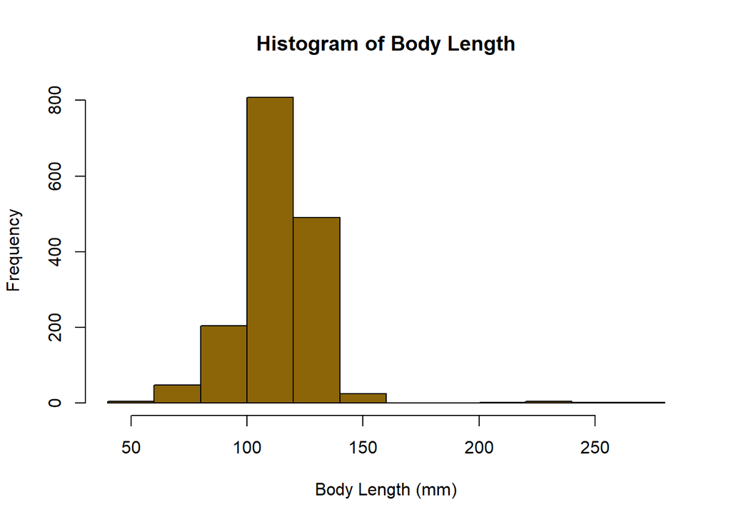

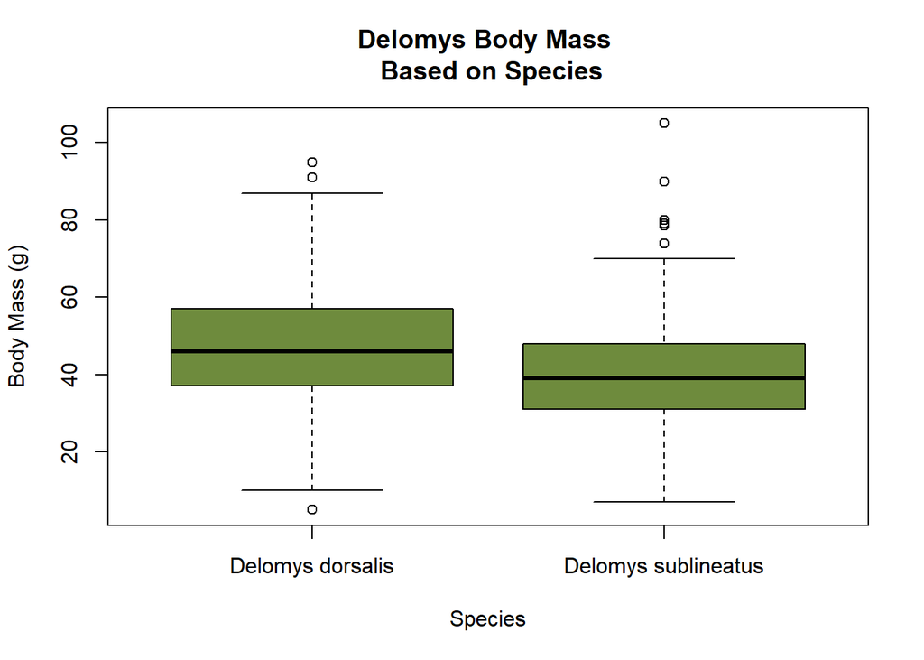

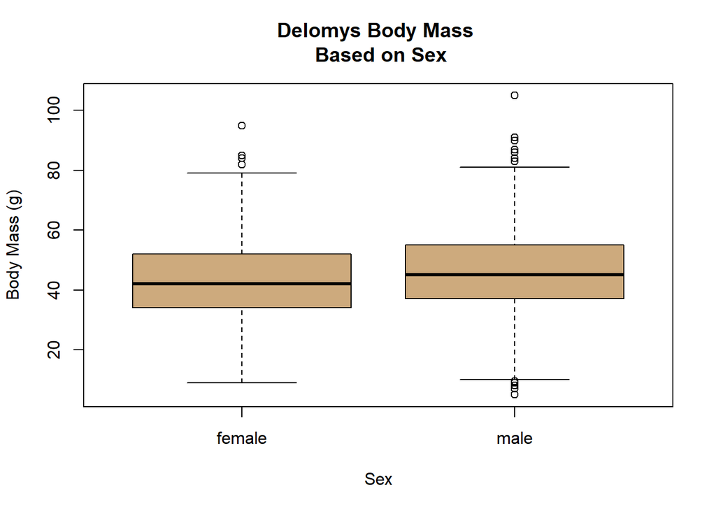

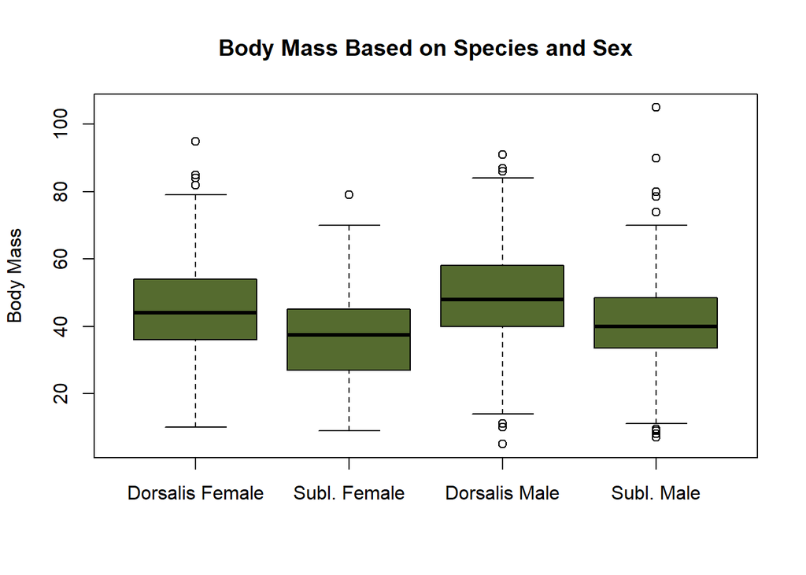

## Question 1

Qualitatively describe the relationship between body mass and length. Does the relationship seem linear, curved, nonexistent?

Body mass and body length seem to be linearly-correlated with higher body lengths yielding higher body masses (a positive correlation). Despite this trend, the slope of the relationship is not steep and there are still quite a few outliers that may blur the analysis.

## Question 2

Qualitatively describe the shapes of the histograms. Do the data appear normally-distributed? Explain why or why not.

The body mass histogram seems very normally-distributed with an even spread within the bell-shaped curve structure. The body length histogram seems less normally-distributed but still follows somewhat of a bell-shaped curve. Most of the data seems to fall in a single bin (100-125mm), visually skewing the data. The body length histogram also reveals some outliers that are quite far to the right of the rest of the data (around 225mm).

## Question 3

Using both the histograms and normality tests, do you think the (unconditioned) body masses and body length are normally-distributed?

Although visual inspection of the histograms for both body mass and body length suggest that the data are more-or-less normally-distributed, the normality tests would suggest otherwise. The Shapiro-Wilk tests for both columns of data (body mass and body length) returned a highly-significant p-value indicating a non-normal distribution. Given both assessments of the data, I am inclined to accept that the data are not normally-distributed due to the results of the normality tests.

## Question 4

Examine the conditional boxplots. Describe any graphical evidence you see for body mass differences based on species and/or sex.

# Model Building

```r
fit1 <- lm(delomys$body_length ~ delomys$body_mass)
fit2 <- lm(delomys$body_mass ~ delomys$sex)
aov(fit2)
```

```
## Call:
##    aov(formula = fit2)
##
## Terms:
##                 delomys$sex Residuals
## Sum of Squares       3061.7  346507.1
## Deg. of Freedom           1      1578
##
## Residual standard error: 14.81844
## Estimated effects may be unbalanced
## 5 observations deleted due to missingness
```

```r
fit3 <- lm(delomys$body_mass ~ delomys$binomial)
aov(fit3)
```

```
## Call:
##    aov(formula = fit3)
##
## Terms:
##                 delomys$binomial Residuals
## Sum of Squares           21289.7  330164.4
## Deg. of Freedom                1      1583
##
## Residual standard error: 14.44191
## Estimated effects may be unbalanced
```

```r
fit4 <- lm(body_mass ~ sex + binomial, data = delomys)
aov(fit4)
```

```
## Call:
##    aov(formula = fit4)
##
## Terms:
##                      sex binomial Residuals
## Sum of Squares    3061.7  23727.1  322780.0
## Deg. of Freedom        1        1      1577
##
## Residual standard error: 14.30663
## Estimated effects may be unbalanced
## 5 observations deleted due to missingness
```

```r
fit5 <- lm(body_mass ~ sex * binomial, data = delomys)
aov(fit5)
```

```
## Call:
##    aov(formula = fit5)
##
## Terms:
##                      sex binomial sex:binomial Residuals
## Sum of Squares    3061.7  23727.1          0.8  322779.2
## Deg. of Freedom        1        1            1      1576
##
## Residual standard error: 14.31115
## Estimated effects may be unbalanced
## 5 observations deleted due to missingness
```

# Model Diagnostics

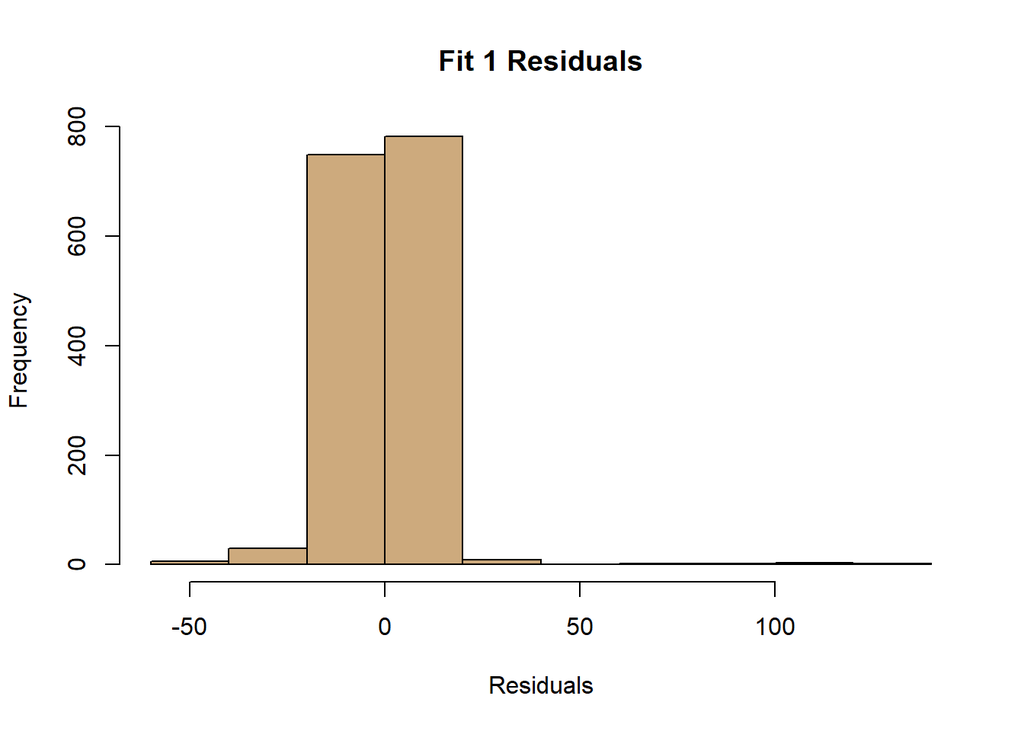

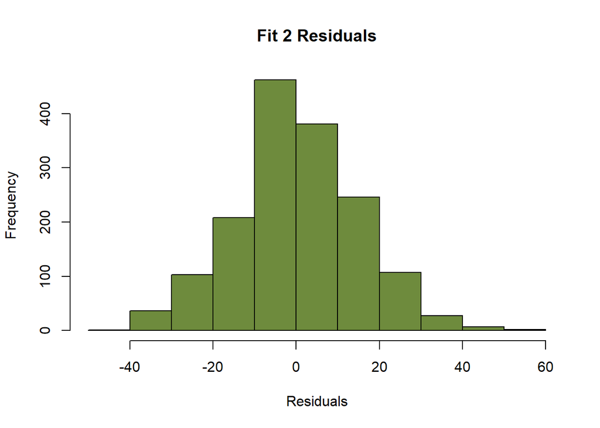

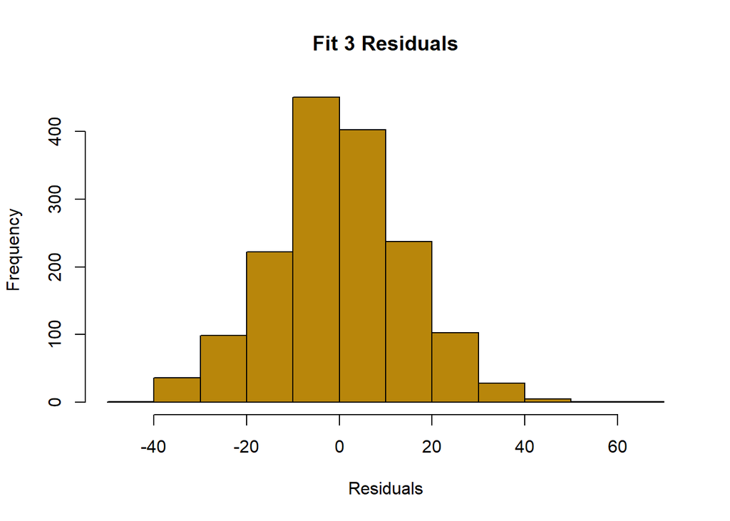

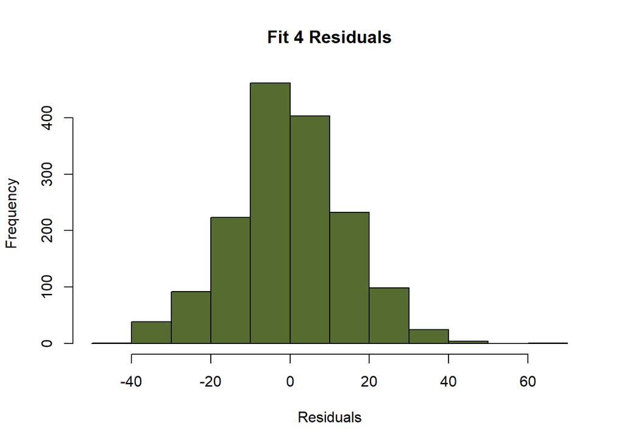

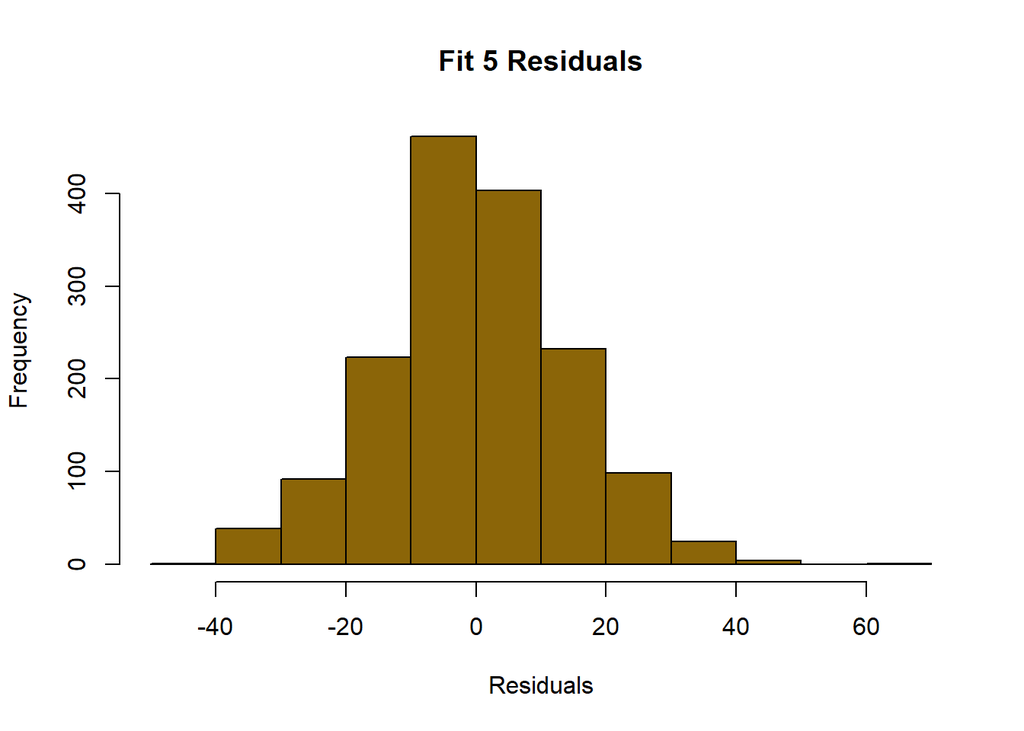

```r
shapiro.test(residuals(fit1))
```

```
##
##  Shapiro-Wilk normality test
##
## data:  residuals(fit1)
## W = 0.73462, p-value < 2.2e-16
```

```r
shapiro.test(residuals(fit2))
```

```
##
##  Shapiro-Wilk normality test
##
## data:  residuals(fit2)
## W = 0.99563, p-value = 0.0001541
```

```r
shapiro.test(residuals(fit3))
```

```
##
##  Shapiro-Wilk normality test
##
## data:  residuals(fit3)
## W = 0.99535, p-value = 8.103e-05
```

```r
shapiro.test(residuals(fit4))
```

```
##
##  Shapiro-Wilk normality test
##
## data:  residuals(fit4)
## W = 0.99525, p-value = 6.805e-05
```

```r
shapiro.test(residuals(fit5))
```

```
##
##  Shapiro-Wilk normality test
##
## data:  residuals(fit5)
## W = 0.99526, p-value = 6.816e-05
```

## Question 5

What do you conclude about residual normality based on the numerical and graphical diagnostics?

All of the models seem to have non-normal residuals based on the Shapiro-Wilk tests. Although the histograms make the residuals appear normally-distributed, the Shapiro-Wilk tests all resulted in p-values below the alpha significance value of p = 0.05.

## Question 6

Are violations of the normality assumption equally severe for all the models?

All of the ANOVAs seem to violate the assumption of normality quite equally, bu the first model (the linear model of body mass vs. body length) violates the assumption of normality by orders of magnitude more.

# Model Interpretation

```r
knitr::kable(coef(summary(fit1)))
```

|  | Estimate | Std. Error | t value | Pr(>\|t\|) |
| --- | --- | --- | --- | --- |
| (Intercept) | 76.1246565 | 0.9158120 | 83.12258 | 0 |
| delomys$body_mass | 0.8754988 | 0.0196905 | 44.46298 | 0 |

```r
knitr::kable(coef(summary(fit2)))
```

|  | Estimate | Std. Error | t value | Pr(>\|t\|) |
| --- | --- | --- | --- | --- |
| (Intercept) | 42.711465 | 0.5288929 | 80.756355 | 0.0000000 |
| delomys$sexmale | 2.784133 | 0.7456117 | 3.734024 | 0.0001951 |

```r
knitr::kable(coef(summary(fit3)))
```

|  | Estimate | Std. Error | t value | Pr(>\|t\|) |
| --- | --- | --- | --- | --- |
| (Intercept) | 46.752427 | 0.4499933 | 103.89582 | 0 |
| delomys$binomialDelomys sublineatus | -7.683058 | 0.7604562 | -10.10322 | 0 |

```r
knitr::kable(coef(summary(fit4)))
```

|  | Estimate | Std. Error | t value | Pr(>\|t\|) |
| --- | --- | --- | --- | --- |
| (Intercept) | 45.070355 | 0.5556429 | 81.113891 | 0e+00 |
| sexmale | 3.795395 | 0.7259609 | 5.228099 | 2e-07 |
| binomialDelomys sublineatus | -8.193492 | 0.7609985 | -10.766764 | 0e+00 |

```r
knitr::kable(coef(summary(fit5)))
```

|  | Estimate | Std. Error | t value | Pr(>\|t\|) |
| --- | --- | --- | --- | --- |
| (Intercept) | 45.0554562 | 0.6052973 | 74.4352459 | 0.0000000 |
| sexmale | 3.8280908 | 0.8966667 | 4.2692460 | 0.0000208 |
| binomialDelomys sublineatus | -8.1417394 | 1.1281046 | -7.2171847 | 0.0000000 |
| sexmale:binomialDelomys sublineatus | -0.0950187 | 1.5285856 | -0.0621612 | 0.9504424 |

```r
knitr::kable(anova(fit2))
```

|  | Df | Sum Sq | Mean Sq | F value | Pr(>F) |
| --- | --- | --- | --- | --- | --- |
| delomys$sex | 1 | 3061.678 | 3061.6779 | 13.94294 | 0.0001951 |
| Residuals | 1578 | 346507.131 | 219.5863 | NA | NA |

```r
knitr::kable(anova(fit3))
```

|  | Df | Sum Sq | Mean Sq | F value | Pr(>F) |
| --- | --- | --- | --- | --- | --- |
| delomys$binomial | 1 | 21289.68 | 21289.6805 | 102.0751 | 0 |
| Residuals | 1583 | 330164.45 | 208.5688 | NA | NA |

```r
knitr::kable(anova(fit4))
```

|  | Df | Sum Sq | Mean Sq | F value | Pr(>F) |
| --- | --- | --- | --- | --- | --- |
| sex | 1 | 3061.678 | 3061.6779 | 14.95838 | 0.0001144 |
| binomial | 1 | 23727.134 | 23727.1342 | 115.92320 | 0.0000000 |
| Residuals | 1577 | 322779.997 | 204.6798 | NA | NA |

```r
knitr::kable(anova(fit5))
```

|  | Df | Sum Sq | Mean Sq | F value | Pr(>F) |
| --- | --- | --- | --- | --- | --- |
| sex | 1 | 3.061678e+03 | 3.061678e+03 | 14.948932 | 0.0001150 |
| binomial | 1 | 2.372713e+04 | 2.372713e+04 | 115.849977 | 0.0000000 |
| sex:binomial | 1 | 7.913846e-01 | 7.913846e-01 | 0.003864 | 0.9504424 |
| Residuals | 1576 | 3.227792e+05 | 2.048091e+02 | NA | NA |

## Question 7

What is the magnitude of the mass/length relationship?

As mass increases by 1 unit, body length also increases by 0.875mm.

## Question 8

What is the expected body length of an an animal that weighs 100g?

76mm + 100*0.875mm = 163.5mm

## Question 9

What is the expected body length of an animal that weighs 0g?

The intercept value: 76.125mm

## Question 10

What is the base level for sex?

Female

## Question 11

What is the base level for binomial?

Delomys dorsalis

## Question 12

Which sex is heavier?

Males

## Question 13

Which species is heavier?

Delomys dorsalis

## Question 14

Are sex and species significant predictors for body mass?

Yes, both sex and species are significant predictors of body mass.

## Question 15

Is there a significant interaction?

No, there is no significant interaction between sex and species.

## Question 16

# Model Comparison

```r
AIC(fit1)
```

```
## [1] 12291.67
```

```r
AIC(fit2)
```

```
## [1] 13006.8
```

```r
AIC(fit3)
```

```
## [1] 12966.36
```

```r
AIC(fit4)
```

```
## [1] 12896.73
```

```r
AIC(fit5)
```

```
## [1] 12898.72
```

## Question 17

Which two models have the lowest AIC?

Fit 1 and fit 4 have the lowest AIC values.

## Question 18

Which of the two models with lowest AIC scores would you select?